# The Complex Terminating-LARS (T-LARS) Method: Usage and Simulations

Fabian Scheidt<sup>#</sup>, Jasin Machkour <sup>#</sup>, Michael Muma<sup>#</sup> <sup>#</sup>Technische Universität Darmstadt

2024-07-16

# Motivation

This package implements the **Complex Terminating-LARS (CTLARS)** algorithm. It computes the solution path of the CTLARS algorithm. The CTLARS algorithm is a variation of a complex LARS algorithm first described in [1] and appends dummy predictors to the original predictor matrix and terminates the forward-selection process after a pre-defined number of dummy variables has been selected. The idea was first introduced by its real number space counterpart the **Terminating-LARS (T-LARS)** algorithm according to [2] itself inspired from the original work on the **Least Angle Regression** algorithm [3].

The motivation is the same as with its cousing. The classical LARS algorithm computes the entire solution path without stopping early. However, for a variety of applications there exists very little or no useful information in later steps or the solution path, and in later step usually only non-active (null) variables are selected. Stopping early benefits to decrease computation time, while the accuracy is not reduced.

In the following, we show how to use the package and give an intuitive idea of why terminating the solution path early is a reasonable approach in high-dimensional complex valued data and spare variable selection. The answer is simply, that in most applications active variables enter the solution path earlier compared to nulls!

You can open the help pages with:

```r
library(ctlars)
help(package = ctlars)
?`ctlars-package`
?ctlars
?FDP
?generate_ccg_data
?plot.ctlars
?simulate_model_TPR_FDR
?TPP
?WCCCGauss_data
?WCCCGauss_data_small
```

To cite the package `ctlars` in publications use

```r
# some future citation:
citation("ctlars")
```

$$\DeclareMathOperator{\FDP}{FDP}
\DeclareMathOperator{\FDR}{FDR}
\DeclareMathOperator{\TPP}{TPP}
\DeclareMathOperator{\TPR}{TPR}
\newcommand{\A}{\mathcal{A}}
\newcommand{\coloneqq}{\mathrel{\vcenter{:}}=}$$

# Installation

Currently no public installation is available.

```r
install.packages("devtools")
devtools::install_github("to/be/announced")
```

# Quick Start

In the following, we illustrate the basic usage of the `ctlars` package for performing variable selection in space high-dimensional complex data space, using the CTLARS algorithm.

1. **First**, we generate high-dimensional Gaussian data set with sparse support.

```r
library(ctlars)

generate_simdata <- FALSE
if (generate_simdata) {
  n <- 100
  p <- 150
  beta_cardinality <- 5
  set.seed(42)

  # generate some data
  data <- generate_ccg_data(n,
                            p,
                            mean_xr = 0,
                            sd_xr = 1,
                            mean_xi = 0,
                            sd_xi = 1,
                            beta_cardinality = beta_cardinality,
                            noise_power = 1,
                            set_snr = TRUE,
                            snr_is_linear = TRUE,
                            snr_val_linear = 2,
                            snr_val_db = 10)

} else {
  data("WCCCGauss_data")
  data <- WCCCGauss_data
}
```

2. **Second**, we generate a dummy matrix containing `n` rows and `num_dummies` dummy predictors sampled from a white circularly centered symmetric complex Gaussian and append it to the original predictor matrix.

```r
 # Append dummies
 set.seed(789)
 update_data <- function(data_lst, num_dummies = p) {
   p <- ncol(data_lst$X)
   n <- nrow(data_lst$X)

   data_lst$X <- cbind(data_lst$X,
     matrix(complex(real = stats::rnorm(n * num_dummies, sd = 1),
                    imag = stats::rnorm(n * num_dummies, sd = 1)),
            nrow = n, ncol = num_dummies)
   )

   data_lst$num_dummies <- num_dummies
   data_lst$n <- n
   data_lst$p <- p

   return(data_lst)
 }
 data <- update_data(data, num_dummies = ncol(data$X))
```

3. **Third**, we generate an object of class `ctlars` and supply the information:

```r
# Run complex terminating lars algorithm
# ----------------------------------------
ctlars_obj <- ctlars::ctlars$new(data$X,
                                  data$y,
                                  num_dummies = data$num_dummies
                                  )
```

4. **Fourth**, we perform on CTLARS step on `ctlars_obj`, i.e., the CTLARS algorithm is run until **t_stop = 1** dummy has entered the solution path and stops there:

```r
ctlars_obj$execute_clars_step(t_stop = 1, early_stop = TRUE, use_chol = TRUE)
```

```
#> complex LARS iteration 1
#> complex LARS iteration 2
#> complex LARS iteration 3
#> complex LARS iteration 4
#> complex LARS iteration 5
#> complex LARS iteration 6
#> complex LARS iteration 7
#> complex LARS iteration 8
#> complex LARS iteration 9
#> complex LARS iteration 10
#> complex LARS iteration 11
#> complex LARS iteration 12
#> complex LARS iteration 13
```

5. **Five** We evaluate the selection results after **t_stop = 1** dummies have been selected.

```r
# Test
# ----------------------------------------
cat("Proposed index set by CLARS: ", ctlars_obj$get_active_set(), "\n")
```

```
#> Proposed index set by CLARS:  50 113 138 146 63 77 55 18 127 78 252 114 132
```

```r
cat("True support: ", drop(data$support), "\n")
```

```
#> True support:  50 146 113 138 63
```

```r
cat("Proposal in true support: ",
     intersect(ctlars_obj$get_active_set(), drop(data$support)), "\n")
```

```
#> Proposal in true support:  50 113 138 146 63
```

```r
cat("Dummies in proposal: ", ctlars_obj$get_active_dummies(), "\n")
```

```
#> Dummies in proposal:  252
```

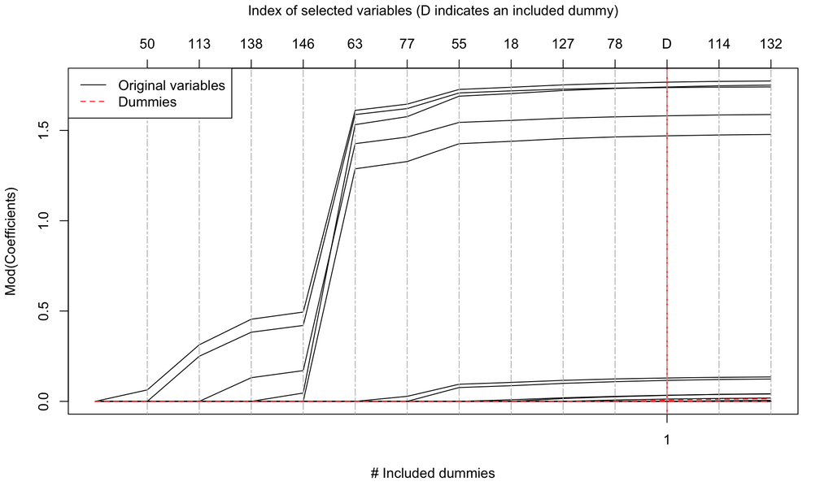

```r
plot(ctlars_obj)
```

# CTLARS Warm Starts

The object `ctlars_obj` stores the state information and, therefore, allows for warm starts. After performing a CTLARS step, e.g., `t_stop = 1`, we can perform another CTLARS, e.g., with `t_stop = 5`. That means the algorithm iterates now till `5` dummies have been selected. Subsequently, we plot again the solution path.

- **T_stop = 5**:

```r
ctlars_obj$execute_clars_step(t_stop = 5)
```

```
#> complex LARS iteration 14
#> complex LARS iteration 15
#> complex LARS iteration 16
#> complex LARS iteration 17
#> complex LARS iteration 18
#> complex LARS iteration 19
```

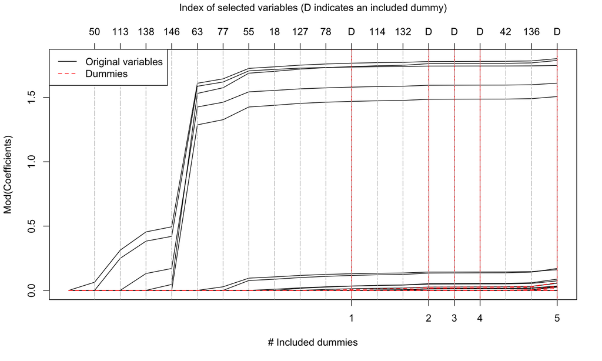

```r
plot(ctlars_obj)
```

Of course these sort of warm starts deliver the same result, as if we had started from scratch until `t_stop = 5`.

```r
# Try a second example with t_stop = 5
# ---------------------------------------
ctlars_obj <- ctlars$new(data$X,
                         data$y,
                         has_intercept = FALSE,
                         num_dummies = data$num_dummies)

ctlars_obj$execute_clars_step(t_stop = 5, early_stop = TRUE)
```

```
#> complex LARS iteration 1
#> complex LARS iteration 2
#> complex LARS iteration 3
#> complex LARS iteration 4
#> complex LARS iteration 5
#> complex LARS iteration 6
#> complex LARS iteration 7
#> complex LARS iteration 8
#> complex LARS iteration 9
#> complex LARS iteration 10
#> complex LARS iteration 11
#> complex LARS iteration 12
#> complex LARS iteration 13
#> complex LARS iteration 14
#> complex LARS iteration 15
#> complex LARS iteration 16
#> complex LARS iteration 17
#> complex LARS iteration 18
#> complex LARS iteration 19
```

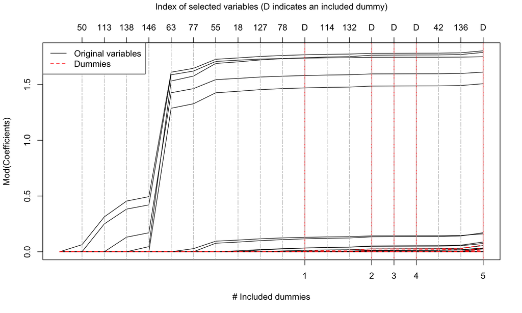

```r
plot(ctlars_obj)
```

# CTLARS Full Solution Path

The algorithm allows also to compute the whole solution path.

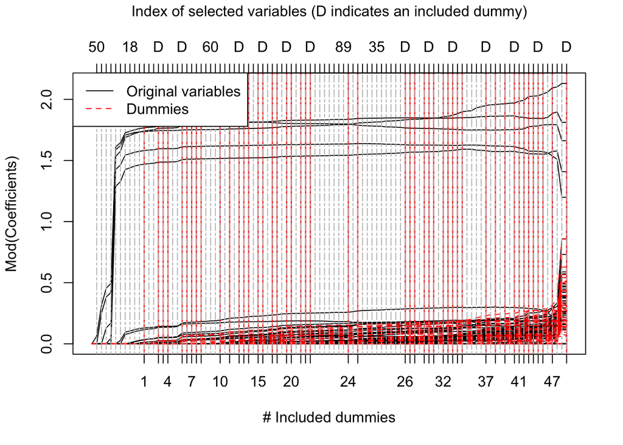

```r
ctlars_obj <- ctlars$new(data$X,
                          data$y,
                          has_intercept = FALSE,
                          num_dummies = data$num_dummies,
                          verbose = FALSE)

ctlars_obj$execute_clars_step(t_stop = 1, early_stop = FALSE)

plot(ctlars_obj)
```

# FDR and TPR

From a statistical point of view, it is desirable to use a variable selection method that allows for controlling the expected value of the FDP at a user-defined target level $\alpha \in [0, 1]$ while maximizing the number of selected variables. These type of methods exist and are called false discovery rate (FDR)-controlling methods.

**Definitions** (FDR and TPR) Let $\widehat{\A} \subseteq \lbrace 1, \ldots, p \rbrace$ be the set of selected variables, $\A \subseteq \lbrace 1, \ldots, p \rbrace$ the set of true active variables, $| \widehat{\A} |$ the cardinality of $\widehat{\A}$, and define $1 \lor a \coloneqq \max\lbrace 1, a \rbrace$, $a \in \mathbb{R}$. Then, the false discovery rate (FDR) and the true positive rate (TPR) are defined by
$$\FDR \coloneqq \mathbb{E} \big[ \FDP \big] \coloneqq \mathbb{E} \left[
\dfrac{\big| \widehat{\A} \backslash \A \big|}{1 \lor \big| \widehat{\A}
\big|} \right]$$

and

$$\TPR \coloneqq \mathbb{E} \big[ \TPP \big] \coloneqq \mathbb{E} \left[
\dfrac{| \A \cap \widehat{\A} |}{1 \lor | \A |} \right],$$

respectively.

```r
 # Evaluate FDP and TPP
 # ----------------------------------------
 chosen <- ctlars_obj$get_active_set()
 # remove dummies
 chosen <- setdiff(
   chosen, ctlars_obj$get_active_dummies()
 )
 FDP(chosen, drop(data$support))
```

```
#> [1] 0.9038462
```

```r
 TPP(chosen, drop(data$support))
```

```
#> [1] 1
```

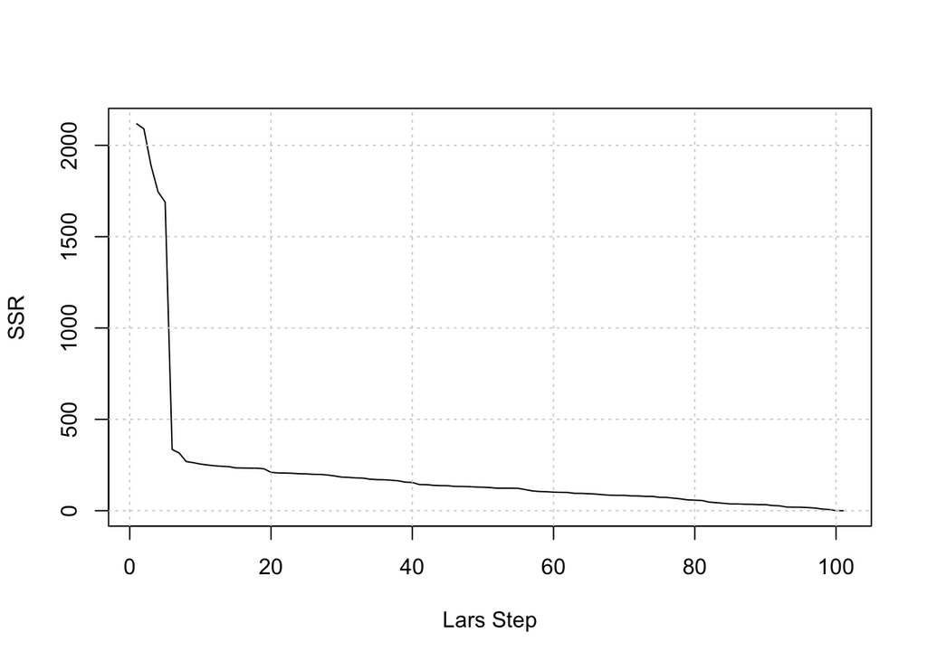

```r
 # Plot R2 and SSR
 # ------------------
 plot(ctlars_obj$get_ssr(), type = "l", xlab = "Lars Step", ylab = "SSR")
 grid()
```

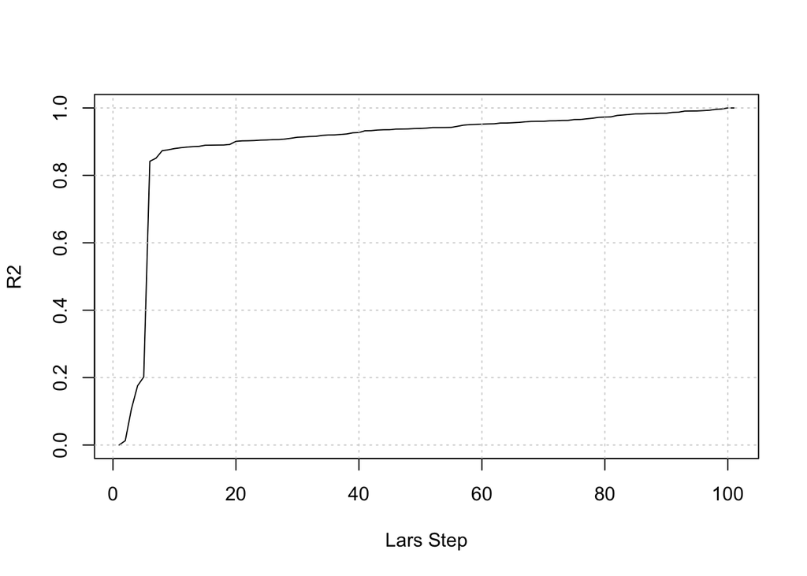

```r
 plot(ctlars_obj$get_r2(), type = "l", xlab = "Lars Step", ylab = "R2")
 grid()
```

# Simulations

We conduct Monte Carlo simulations and plot the resulting averaged FDP and TPP over the number of included dummies T. Note that the averaged FDP and TPP are estimates of the FDR and TPR, respectively.

```r
library(ctlars)

t_vec <- c(1, 2, 5, 10, 20, 50, 100)
sim_res <- simulate_model_TPR_FDR(
   t_vec,
   MC = 500,
   n = 100,
   p = 300,
   num_actives = 10,
   num_dummies = 300,
   set_snr = FALSE,
   verbose = FALSE
   )
```

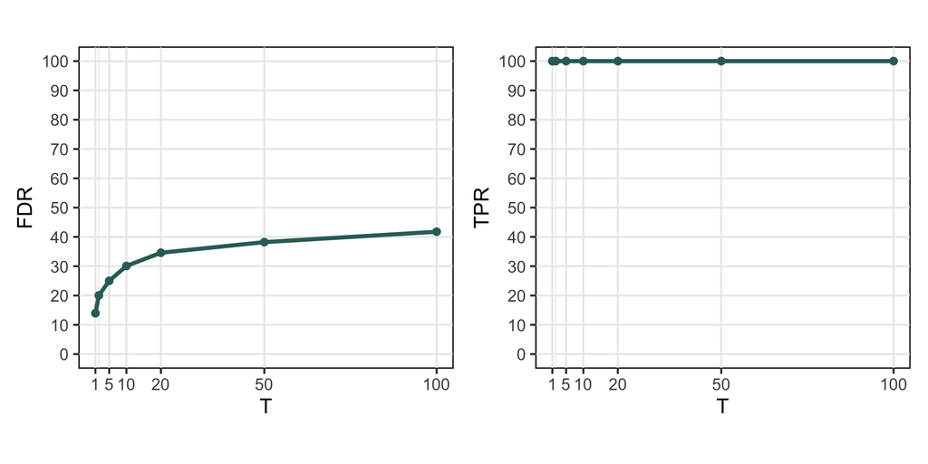

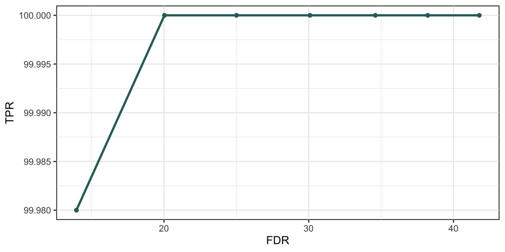

As with the real T-LARS algorithm, we observe again that with growing number of included dummies `t` the FDR and TPR increases. Moreover, we can again identify the trade-off in the receiver-operating curve between FDR and TPR.

# Outlook

The CTLARS algorithm is going to be a major building block the complex T-Rex selector and its future variants. Track its developement!

# References

[1]

J. Graff, M. J. Ringuette, T. Singh, and F. D. Lagor, “Reduced-order modeling for dynamic mode decomposition without an arbitrary sparsity parameter,” *AIAA Journal*, vol. 58, no. 9, pp. 3919–3931, 2020.

[2]

J. Machkour, M. Muma, and D. P. Palomar, “The terminating-random experiments selector: Fast high-dimensional variable selection with false discovery rate control,” *arXiv preprint arXiv:2110.06048*, 2022.

[3]

B. Efron, T. Hastie, I. Johnstone, and R. Tibshirani, “Least angle regression,” *Ann. Statist.*, vol. 32, no. 2, pp. 407–499, 2004.